# Day3RExercise_WangAria

Aria Wang

9/19/2019

## Day 3: Data viz with ggplot - Exercises

This document contains the instructions for exercises during the Day 3: ggplot session, drawn from the slides. Suggested answers are included in the [slides](https://msia.github.io/bootcamp-2018/lectureslides/day3_R-ggplot_slides_kr#/).

### Exercise 1: Scatterplot

Using the gapminder07 data, create a scatterplot of the natural log of `gdpPercap` as a function of the natural log of `pop`. Give it a title and axis labels.

Remember, you will need three functions: `ggplot()`, `geom_point()`, and `labs()`.

```r
library(ggplot2)
source(here::here('data/day3_objects.R'))
```

[output not shown]

[output not shown]

[output not shown]

```
## here() starts at /Users/xiaohanwang/Desktop/NorthwesternU/bootcamp/bootcamp-2019
```

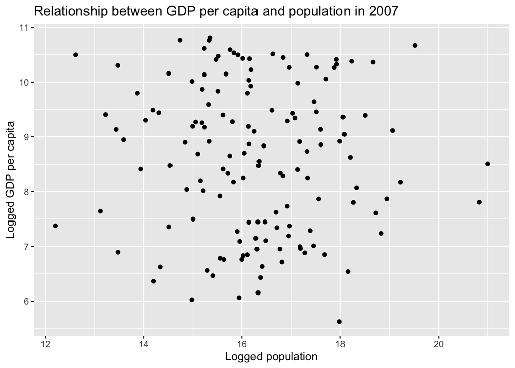

```r
ggplot(gapminder07) +
  geom_point(aes(x = log(pop), y = log(gdpPercap))) +
  labs(title = "Relationship between GDP per capita and population in 2007",
       y = "Logged GDP per capita", x = "Logged population")
```

### Exercise 2: Hydro power generated over time

Task: Plot a column chart hydroelectric power generated over time.

Hint: There are two types of hydroelectric sources in the data: `large_hydro` and `small_hydro`.

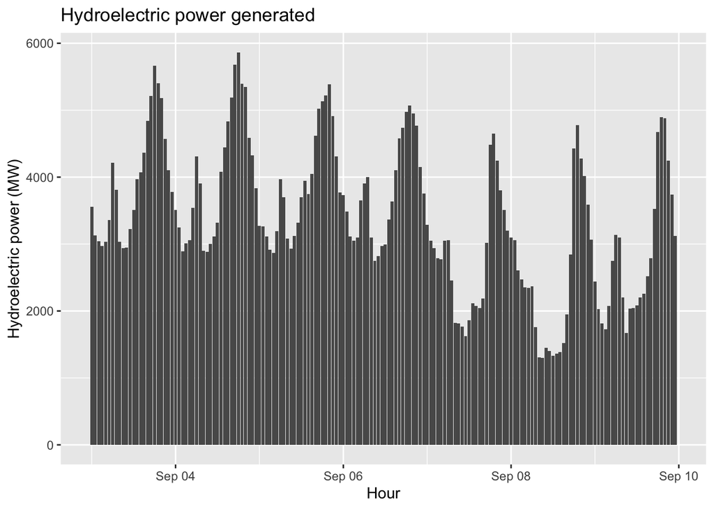

```r
library(dplyr)
long_gen %>%
    filter(source %in% c('large_hydro', 'small_hydro')) %>%
    group_by(datetime) %>%
    summarise(output_sum = sum(output)) %>%
    ggplot() + geom_col(aes(x = datetime, y = output_sum)) +
    labs(title = 'Hydroelectric power generated', x = 'Hour', y = 'Hydroelectric power (MW)')
```

### Exercise 3: Total output per source

Task: Create a column chart that shows the total output per source.

- Change the color of the columns to `"darkred"`.
- Add a horizontal line indicating the mean output across all sources. Use the cheatsheet to identify the `geom` function that you need.
- Add a meaningful title and axis labels using `labs()`.

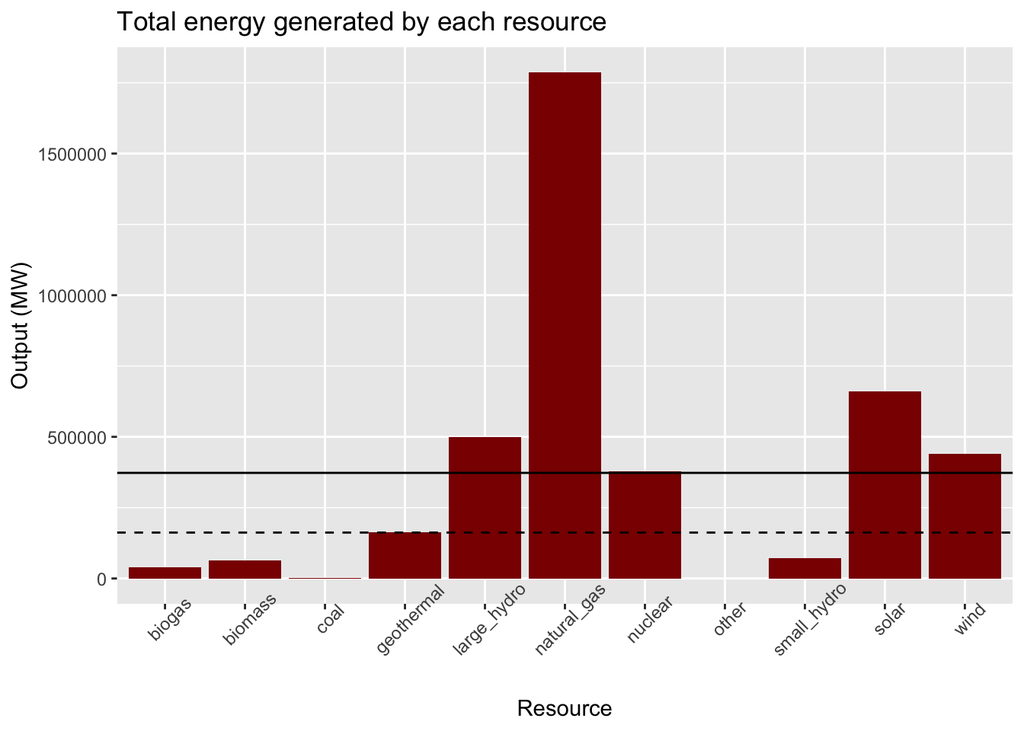

```r
long_gen %>%
    group_by(source) %>%
    summarise(output = sum(output)) %>%
    ggplot() + geom_col(aes(x = source, y = output), fill = 'darkred') +
    geom_hline(aes(yintercept = mean(output))) +
    geom_hline(aes(yintercept = median(output)), linetype = 'dashed') +
    labs(title = 'Total energy generated by each resource', x = 'Resource', y ='Output (MW)') +
    theme(axis.text.x = element_text(angle = 45))
```

### Exercise 4: Colors and fill

Task: Create a line plot that compares generation of wind, solar, and geothermal energy over time.

Bonus: Set the line size to 1.5.

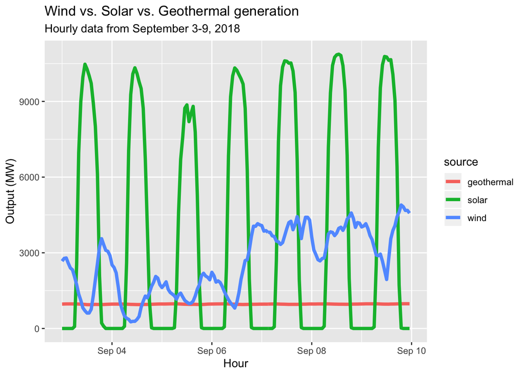

```r
long_gen %>%
    filter(source %in% c('wind', 'solar', 'geothermal')) %>%
    ggplot() +
    geom_line(aes(x = datetime, y = output, group = source, col = source), size = 1.5) +
    labs(title = 'Wind vs. Solar vs. Geothermal generation', y = 'Output (MW)', x = 'Hour',
         subtitle = "Hourly data from September 3-9, 2018")
```

### Exercise 5: Average hourly output by source

Task: Visualize the average output for each hour of the day, grouped by source.

Hint: You need to identify the output per source per hour (e.g. 01:00, 02:00, etc) averaged over all days.

- You will need to prepare your data using both `dplyr` and `lubridate` functions.
- You can choose which `geom`(s) to use, and how to demarcate groups.
- Bonus: use a scale layer to set a color palette (try `"Set3"`) and change the legend name.
- Remember to add `labs()`!

```r
library(lubridate)
```

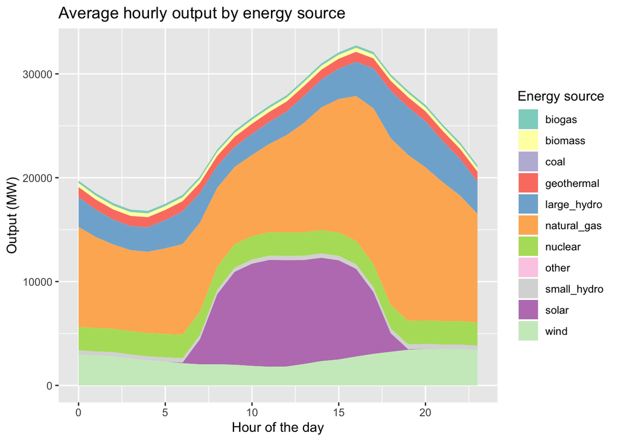

```r
long_gen %>%
    mutate(hour = hour(datetime)) %>%
    group_by(hour, source) %>%
    summarise(mean_output = mean(output, na.rm = T)) %>%
    ggplot() +
    geom_area(aes(x = hour, y = mean_output, fill = factor(source))) +
    scale_fill_brewer(palette = 'Set3', name = 'Energy source') +
    labs(title = 'Average hourly output by energy source', x = 'Hour of the day',
         y ='Output (MW)')
```

### Exercise 6: Facets

Task: Compare generation patterns for each source in facets. Color the lines using the “group” variable in `regroup`.

Remember: - You will need to prepare your data. Think about the variables that you need: source/type, output, and group. - When you pipe modified data into ggplot, remember that you are grouping in two ways: source/type through facets, and group through color.

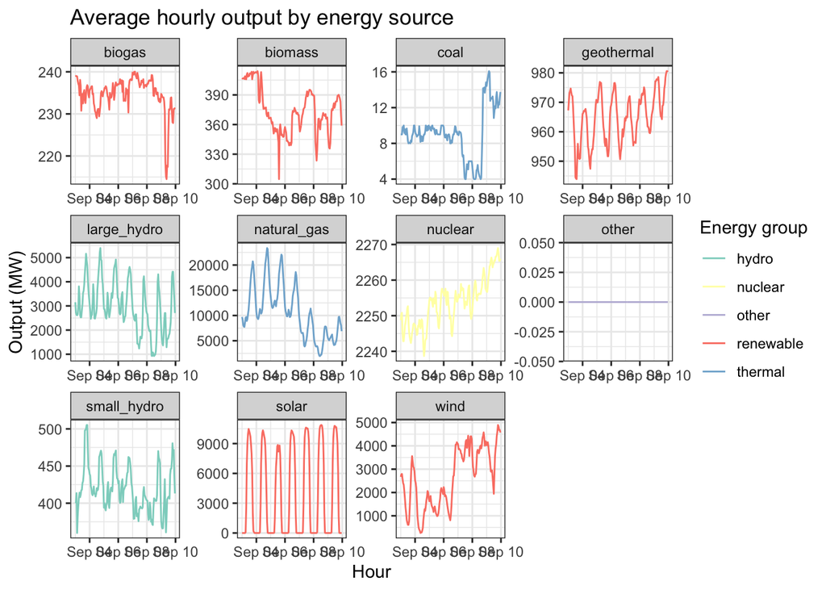

```r
long_gen_group <- merge(long_gen, regroup, by.x = 'source', by.y = 'type')
long_gen_group %>%
    ggplot() +
    geom_line(aes(x = datetime, y = output, col = factor(group))) +
    facet_wrap(~ source, scales = 'free') +
    # specify the choice of scales, in case some sources just have a horizontal line of output
    scale_color_brewer(palette = 'Set3', name = 'Energy group') +
    labs(title = 'Average hourly output by energy source', x = 'Hour', y ='Output (MW)') +
    theme(axis.text.x = element_text(angle = 45), legend.position = "bottom") + theme_bw()
```